# Burglary_DistrictTS_DistrictKriging

August 27, 2015

The beat and district numbers in the data were re-assigned by finding in which new beat/district polygon the point falls and then label that beat/district number. Therefore all violent crime beat and district records have a unified reference which is the new CPD beat/district map.

The evaluation date starts from 2014-08-01 and ends on 2014-08-04. The time series training uses 12-year data before the corresponding testing date.

The time series models were applied to each district. Then uniformly allocate the residuals to each beat, i.e. the temporal model residual of each beat is assumed be the district residual divided by the number of beats in that district.

Variogram models were estimated from recent two-year beat-level residual data. For each district, we calculate an empirical variogram. And if a point on the fine regular grid falls into a district, its spatial interpolation will be done through the Kriging using this district’s variogram. We use only two year data and consider the time intervals up to 14 days to relieve computation burden. In our experiment, we choose the product-sum model with the spherical model for both temporal and spatial terms. One variogram example and its fitting is shown below.

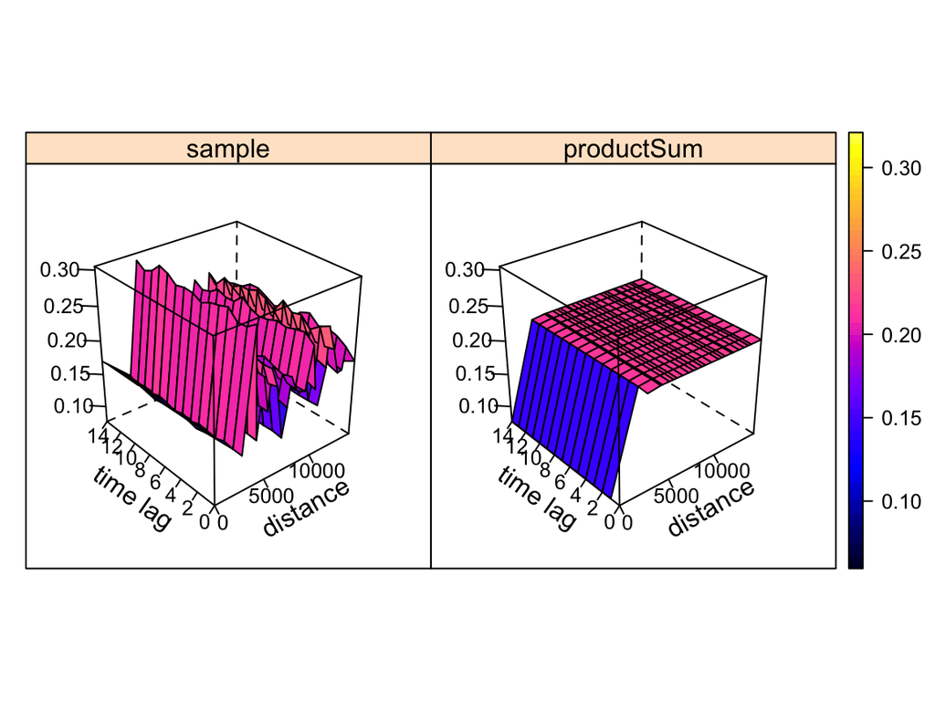

Here shows an example of time series predictions’ and residuals’ distribution (last evaluation example).

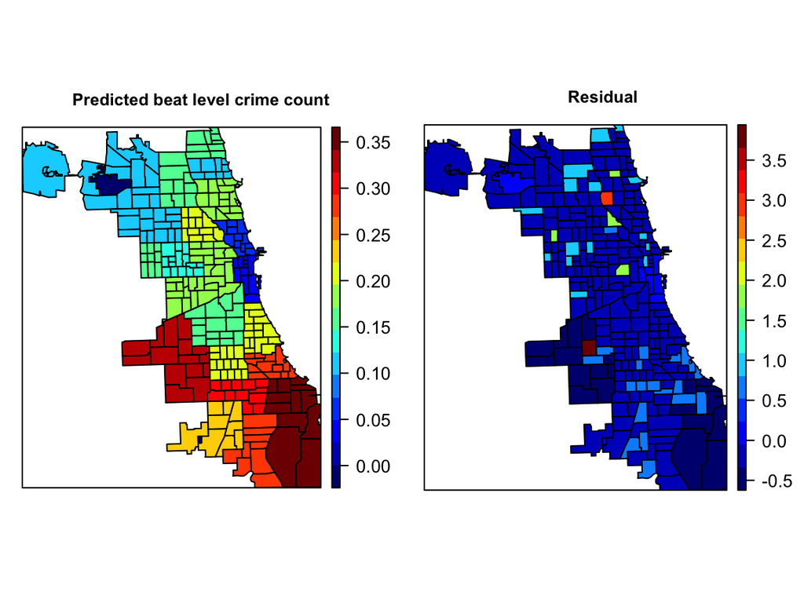

Here is the visualization of prediction results.

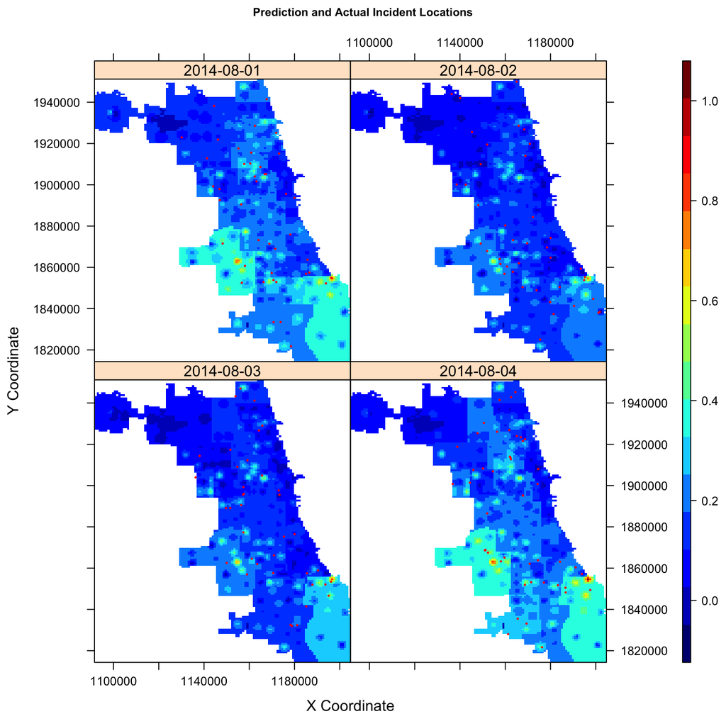

The evaluation is done through sensitivity(TPR)-like comparison between prediction model,long-term density and short-term density. To illustrate the idea, we demonstrate an example below the *sensitivity* plots: first selecting 10% highest pixels (threshold = 0.9 quantile of image histogram) then count how many actual crime incidents happened in these regions. And we do in this fashion for different threshold quantiles to get the *sensitivity* plot.

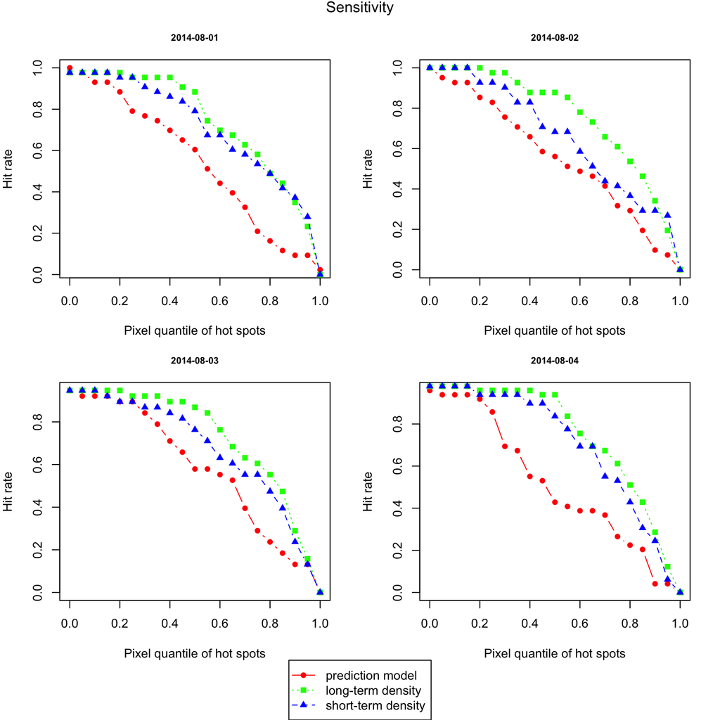

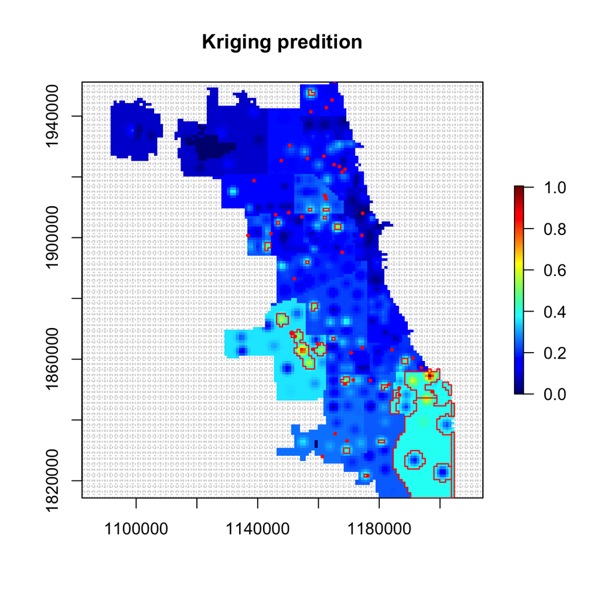

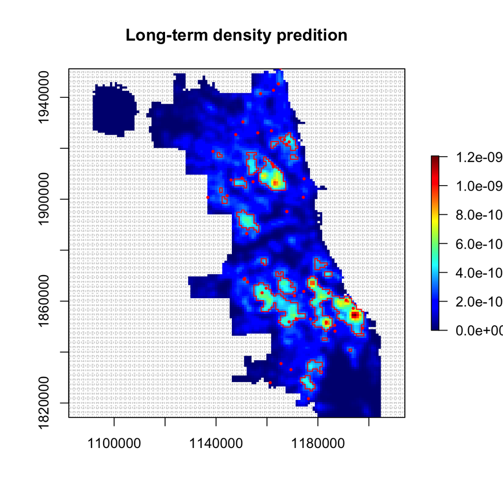

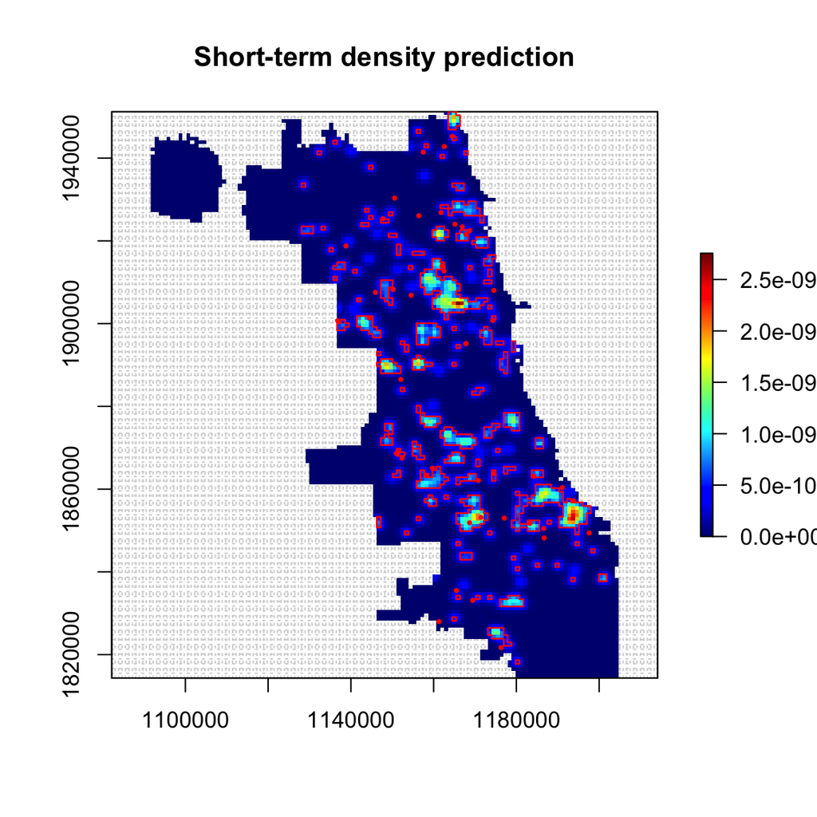